# K-Means

# Tarea 4.

# Ejercicios

Librerias

```r
library('ggplot2')
library('dplyr')
library('GGally')
library('reshape2')
```

**1.** Desarolle el Análisis del Problema Se nos presenta un dataset con ventas al por mayor anules en diferentes categorias de productos, separado por canales y regiones. Si realizamos un buen analisis a estos datos podremos detectar informacion que nos pueda ayudar a encontrar cuales productos se venden más por region o por canal, encontrar correlaciones entre las ventas de estos productos, detectar grupos de posibles clientes basado en el total anual.

Fuente del dataset: https://archive.ics.uci.edu/ml/datasets/Wholesale+customers

**2.** Cargue el archivo Wholesale customers data.csv en una variable

```r
wholesale <- read.csv('Wholesale.csv', header = T, na.strings = '?')
```

**3.** Desarolle el Entendimiento de los Datos

Tenemos datos de Ventas anules por categoria de producto, separado por canales y regiones El canal 1 corresponde a Hoteles/Restaurantes/Cafe El canal 2 corresponde a Retail La region 1 es Lisbon Region 2: Oporto 47 Region 3: Otras Regiones

- Fresh: annual spending (m.u.) on fresh products (Continuous);
- Milk: annual spending (m.u.) on milk products (Continuous);
- Grocery: annual spending (m.u.)on grocery products (Continuous);
- Frozen: annual spending (m.u.)on frozen products (Continuous)
- Detergents_Paper: annual spending (m.u.) on detergents and paper products (Continuous)
- Delicatessen: annual spending (m.u.)on and delicatessen products (Continuous);

```r
glimpse(wholesale)
```

```
## Observations: 440
## Variables: 8
## $ Channel          <int> 2, 2, 2, 1, 2, 2, 2, 2, 1, 2, 2, 2, 2, 2, 2, ...
## $ Region           <int> 3, 3, 3, 3, 3, 3, 3, 3, 3, 3, 3, 3, 3, 3, 3, ...
## $ Fresh            <int> 12669, 7057, 6353, 13265, 22615, 9413, 12126,...
## $ Milk             <int> 9656, 9810, 8808, 1196, 5410, 8259, 3199, 495...
## $ Grocery          <int> 7561, 9568, 7684, 4221, 7198, 5126, 6975, 942...
## $ Frozen           <int> 214, 1762, 2405, 6404, 3915, 666, 480, 1669, ...
## $ Detergents_Paper <int> 2674, 3293, 3516, 507, 1777, 1795, 3140, 3321...
## $ Delicassen       <int> 1338, 1776, 7844, 1788, 5185, 1451, 545, 2566...
```

```r
summary(wholesale)
```

```
##     Channel          Region          Fresh             Milk
##  Min.   :1.000   Min.   :1.000   Min.   :     3   Min.   :   55
##  1st Qu.:1.000   1st Qu.:2.000   1st Qu.:  3128   1st Qu.: 1533
##  Median :1.000   Median :3.000   Median :  8504   Median : 3627
##  Mean   :1.323   Mean   :2.543   Mean   : 12000   Mean   : 5796
##  3rd Qu.:2.000   3rd Qu.:3.000   3rd Qu.: 16934   3rd Qu.: 7190
##  Max.   :2.000   Max.   :3.000   Max.   :112151   Max.   :73498
##     Grocery          Frozen        Detergents_Paper    Delicassen
##  Min.   :    3   Min.   :   25.0   Min.   :    3.0   Min.   :    3.0
##  1st Qu.: 2153   1st Qu.:  742.2   1st Qu.:  256.8   1st Qu.:  408.2
##  Median : 4756   Median : 1526.0   Median :  816.5   Median :  965.5
##  Mean   : 7951   Mean   : 3071.9   Mean   : 2881.5   Mean   : 1524.9
##  3rd Qu.:10656   3rd Qu.: 3554.2   3rd Qu.: 3922.0   3rd Qu.: 1820.2
##  Max.   :92780   Max.   :60869.0   Max.   :40827.0   Max.   :47943.0
```

**4.** Utilizando barplot cree un gráfico de los atributos del dataset, observe las correlaciones entre atributos

Existe una fuerte correlacion entre Grocery y Detergents_Paper

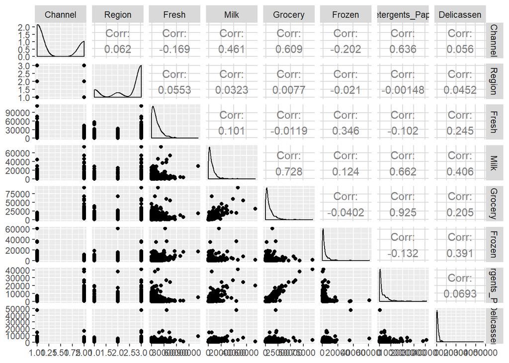

```r
ggpairs(wholesale)
```

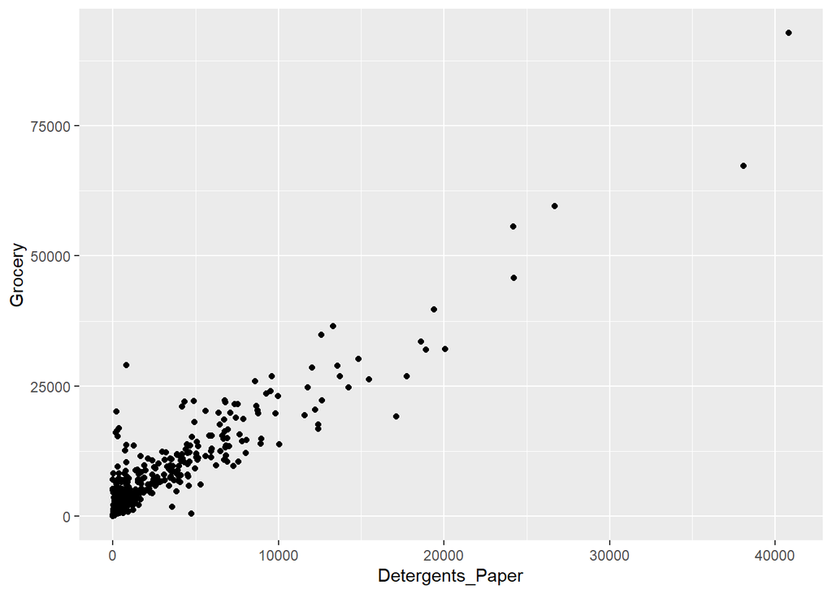

```r
ggplot(wholesale) +
    geom_point(aes(x = Detergents_Paper, y = Grocery))
```

**5.** Explique el siguiente gráfico

En el grafico podemos observar boxplots por cada tipo de producto en los dos Channels existentes #1 y #2 Para algunos productos podemos concluir que existen outliers considerables, como en el caso de Delicassen y Fresh. Aunque para todos los productos existen datos que se salen de la media, o sesgos.

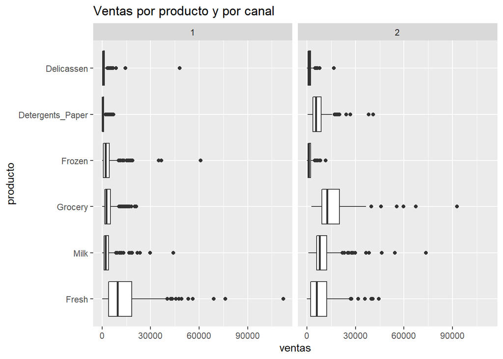

```r
#Grafico
wholesale$Channel <- factor(wholesale$Channel)
wholesale$Region <- factor(wholesale$Region)

ggplot(data = melt(wholesale)) +
  geom_boxplot(aes(x= variable, y = value)) +
  facet_wrap(~Channel) +
  coord_flip() +
  labs(x = 'producto', y  = 'ventas') +
  ggtitle('Ventas por producto y por canal')
```

**6.** Cree un modelo de agrupación K- Means Para agrupar a los clientes con base al consumo, vamos a utilizar solo las variables Fresh, Milk, Grocery, Frozen, Detergents_Paper y Delicassen. En este caso, vamos a intentar agrupar los clientes en 5 grupos diferentes.

```r
#5 Centroides utilizando k-means
modelo.agrupacion <- kmeans(wholesale[,c(3:8)], centers = 5)

#predecir utilizando el modelo para agregar una variable nueva llamada 'cluster' al conjunto de datos
wholesale$cluster <- modelo.agrupacion$cluster

#convertir la variable nueva a un factor
wholesale$cluster <- factor(wholesale$cluster)
```

**7.** Realice al menos 3 modelos cambiando los centroides

```r
#2 Centroides utilizando k-means
wholesale$cluster_2  <- kmeans(wholesale[,c(3:8)], centers = 2)$cluster

#convertir la variable nueva a un factor
wholesale$cluster_2 <- factor(wholesale$cluster)

#3 Centroides utilizando k-means
wholesale$cluster_3 <- kmeans(wholesale[,c(3:8)], centers = 3)$cluster

#convertir la variable nueva a un factor
wholesale$cluster_3 <- factor(wholesale$cluster)

#4 Centroides utilizando k-means
wholesale$cluster_4 <- kmeans(wholesale[,c(3:8)], centers = 5)$cluster

#convertir la variable nueva a un factor
wholesale$cluster_4 <- factor(wholesale$cluster)
```

**8.** Evaluacioón del modelo

```r
# Escriba su código aqui
#Explicacion de los grupos generados
by(wholesale$Fresh, wholesale$cluster, sum)
```

```
## wholesale$cluster: 1
## [1] 379101
## --------------------------------------------------------
## wholesale$cluster: 2
## [1] 212637
## --------------------------------------------------------
## wholesale$cluster: 3
## [1] 1133810
## --------------------------------------------------------
## wholesale$cluster: 4
## [1] 1349777
## --------------------------------------------------------
## wholesale$cluster: 5
## [1] 2204806
```

**9.** Desarolle al menos 5 conclusiones sobre los grupos realizados * Ejemplo: - Las principales características de cada grupo son: - #### Grupo #1: (2do grupo más pequeño) - Principalmente observaciones de la región 3 y el canal 1. - Muy alto consumo de productos frescos. - Bajo consumo de leche. - Bajo consumo de comestibles. - Alto consumo de alimentos congelados. - Bajo consumo de detergentes. - Bajo consumo de delicassen.

```r
modelo.agrupacion$size
```

```
## [1]  80  10  23 223 104
```

**2.** Observaciones de la region 3 (Otras regiones)

```r
wholesale.melted <- melt(wholesale)
#Filtrar por Region 3
wholesale.melted <- wholesale.melted %>%
  filter(Region==3)

#Que producto se vende más en la region 3
by(wholesale.melted$value, wholesale.melted$variable, sum)
```

```
## wholesale.melted$variable: Fresh
## [1] 3960577
## --------------------------------------------------------
## wholesale.melted$variable: Milk
## [1] 1888759
## --------------------------------------------------------
## wholesale.melted$variable: Grocery
## [1] 2495251
## --------------------------------------------------------
## wholesale.melted$variable: Frozen
## [1] 930492
## --------------------------------------------------------
## wholesale.melted$variable: Detergents_Paper
## [1] 890410
## --------------------------------------------------------
## wholesale.melted$variable: Delicassen
## [1] 512110
```

```r
#En cual cluster se compra más productos Fresh
by(wholesale$Fresh, wholesale$cluster, sum)
```

```
## wholesale$cluster: 1
## [1] 379101
## --------------------------------------------------------
## wholesale$cluster: 2
## [1] 212637
## --------------------------------------------------------
## wholesale$cluster: 3
## [1] 1133810
## --------------------------------------------------------
## wholesale$cluster: 4
## [1] 1349777
## --------------------------------------------------------
## wholesale$cluster: 5
## [1] 2204806
```

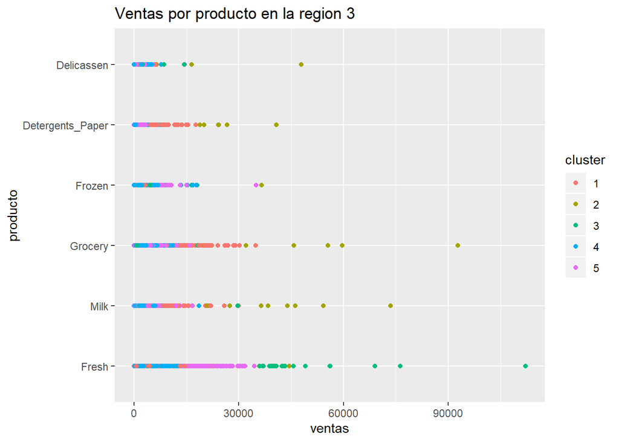

```r
ggplot(wholesale.melted) +
    geom_point(aes(x = value, y = variable, color=cluster)) +
    labs(x = 'ventas', y  = 'producto') +
    ggtitle('Ventas por producto en la region 3')
```

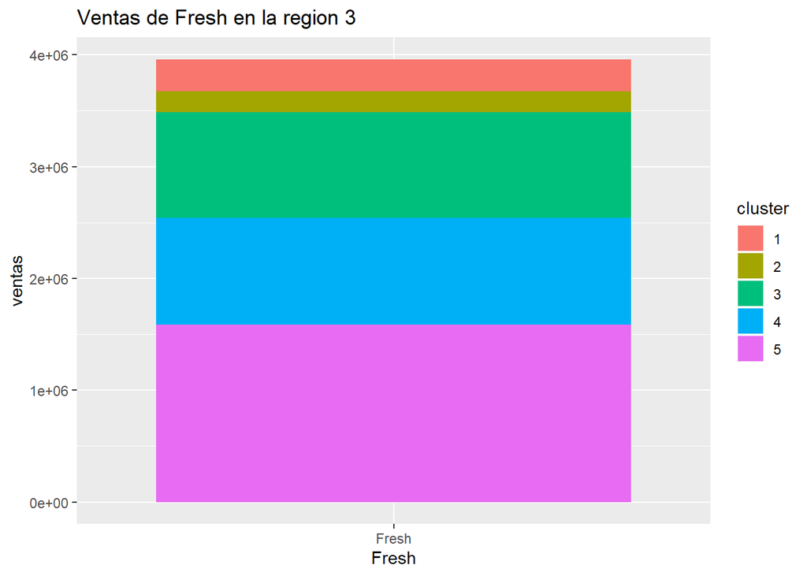

```r
fresh_region3 <- wholesale.melted %>%
  filter(variable=='Fresh')

ggplot(fresh_region3) +
    geom_bar(aes(x = variable, weight = value, fill=cluster)) +
    labs(x = 'Fresh', y  = 'ventas') +
    ggtitle('Ventas de Fresh en la region 3')
```

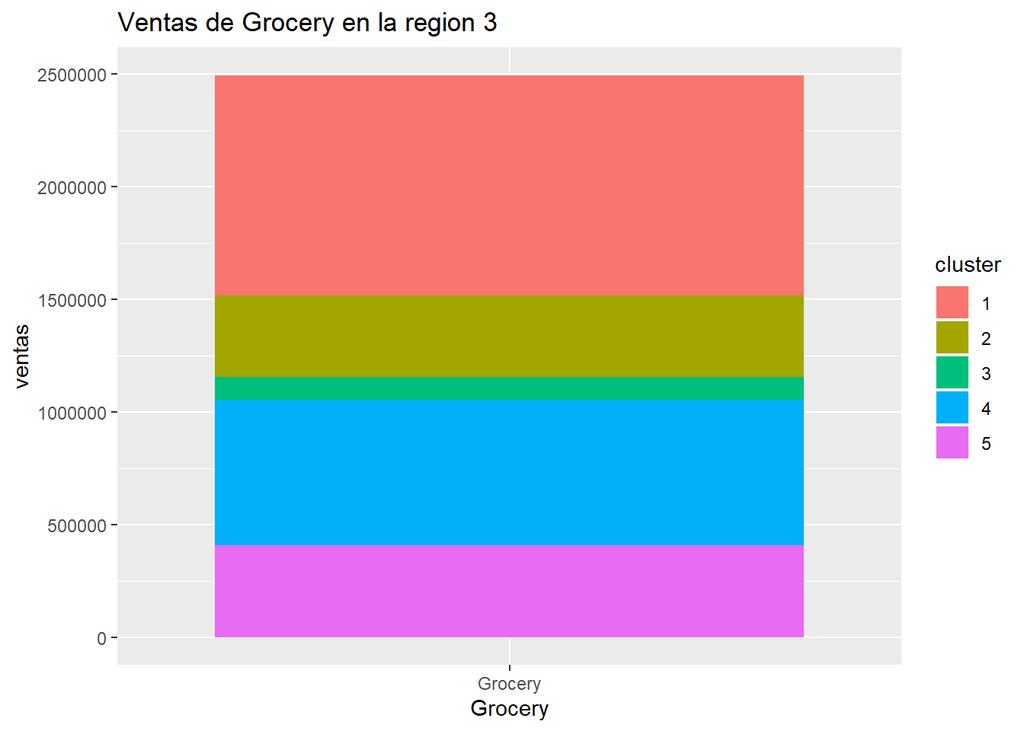

```r
grocery_region3 <- wholesale.melted %>%
  filter(variable=='Grocery')

ggplot(grocery_region3) +
    geom_bar(aes(x = variable, weight = value, fill=cluster)) +
    labs(x = 'Grocery', y  = 'ventas') +
    ggtitle('Ventas de Grocery en la region 3')
```

**3.** Oservaciones del Channel 1 (Horeca)

```r
wholesale.melted <- melt(wholesale)
# Cuanto vende cada Channel
by(wholesale.melted$value, wholesale.melted$Channel, sum)
```

```
## wholesale.melted$Channel: 1
## [1] 7999569
## --------------------------------------------------------
## wholesale.melted$Channel: 2
## [1] 6619931
```

```r
wholesale.melted <- wholesale.melted %>%
  filter(Channel==1)
# Cual producto se vende más en el channel 1
by(wholesale.melted$value, wholesale.melted$variable, sum)
```

```
## wholesale.melted$variable: Fresh
## [1] 4015717
## --------------------------------------------------------
## wholesale.melted$variable: Milk
## [1] 1028614
## --------------------------------------------------------
## wholesale.melted$variable: Grocery
## [1] 1180717
## --------------------------------------------------------
## wholesale.melted$variable: Frozen
## [1] 1116979
## --------------------------------------------------------
## wholesale.melted$variable: Detergents_Paper
## [1] 235587
## --------------------------------------------------------
## wholesale.melted$variable: Delicassen
## [1] 421955
```

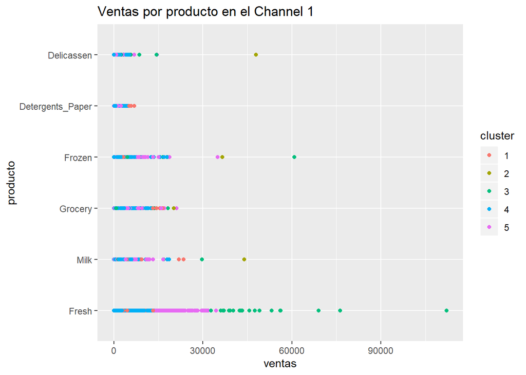

```r
ggplot(wholesale.melted) +
    geom_point(aes(x = value, y = variable, color=cluster)) +
    labs(x = 'ventas', y  = 'producto') +
    ggtitle('Ventas por producto en el Channel 1')
```

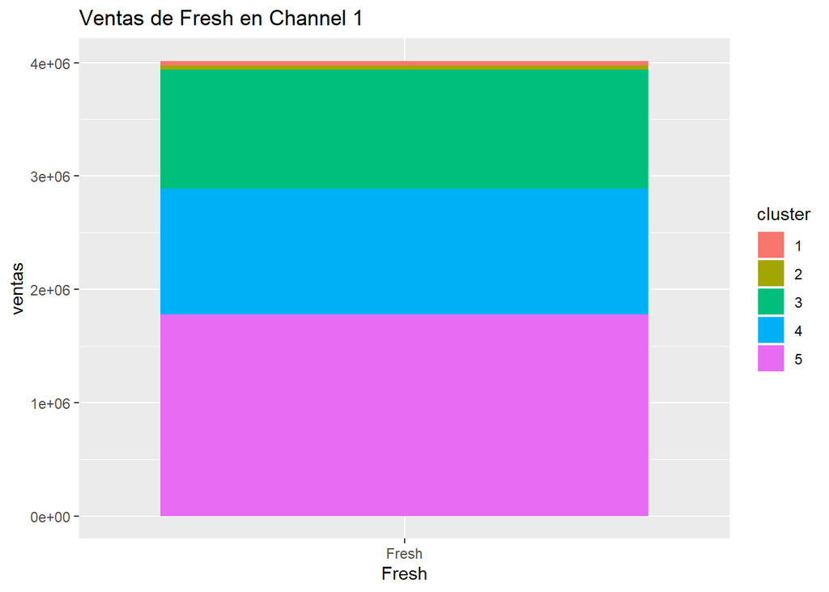

```r
fresh_channel1 <- wholesale.melted %>%
  filter(variable=='Fresh')

ggplot(fresh_channel1) +
    geom_bar(aes(x = variable, weight = value, fill=cluster)) +
    labs(x = 'Fresh', y  = 'ventas') +
    ggtitle('Ventas de Fresh en Channel 1')
```

**4.** Concluciones sobre consumo de leche

```r
wholesale.melted <- melt(wholesale)
#Filtrar por categoria Milk
lactose_sales <- wholesale.melted %>%
  filter(variable=='Milk')
#Cual cluster consume más Milk
by(lactose_sales$value, lactose_sales$cluster, sum)
```

```
## lactose_sales$cluster: 1
## [1] 928721
## --------------------------------------------------------
## lactose_sales$cluster: 2
## [1] 374433
## --------------------------------------------------------
## lactose_sales$cluster: 3
## [1] 114627
## --------------------------------------------------------
## lactose_sales$cluster: 4
## [1] 728388
## --------------------------------------------------------
## lactose_sales$cluster: 5
## [1] 404188
```

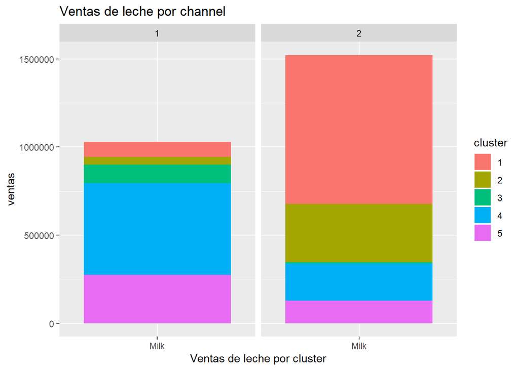

```r
ggplot(lactose_sales) +
    geom_bar(aes(x = variable, weight = value, fill=cluster)) +
    facet_wrap(~Channel) +
    labs(x = 'Ventas de leche por cluster', y  = 'ventas') +
    ggtitle('Ventas de leche por channel')
```

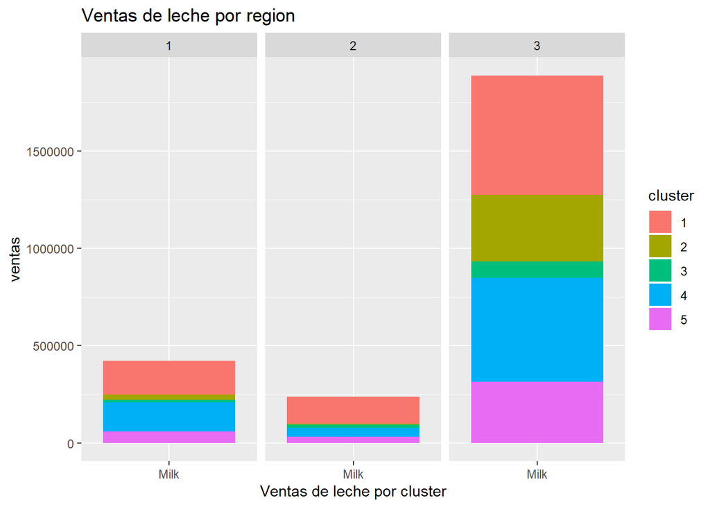

```r
ggplot(lactose_sales) +
    geom_bar(aes(x = variable, weight = value, fill=cluster)) +
    facet_wrap(~Region) +
    labs(x = 'Ventas de leche por cluster', y  = 'ventas') +
    ggtitle('Ventas de leche por region')
```

**5.** Concluciones sobre consumo de detergentes y papel

```r
wholesale.melted <- melt(wholesale)
#Filtrar por categoria Detergents_Paper
detergents_paper <- wholesale.melted %>%
  filter(variable=='Detergents_Paper')
#Cual cluster consume más Detergents_Paper
by(detergents_paper$value, detergents_paper$cluster, sum)
```

```
## detergents_paper$cluster: 1
## [1] 640302
## --------------------------------------------------------
## detergents_paper$cluster: 2
## [1] 216994
## --------------------------------------------------------
## detergents_paper$cluster: 3
## [1] 22132
## --------------------------------------------------------
## detergents_paper$cluster: 4
## [1] 270751
## --------------------------------------------------------
## detergents_paper$cluster: 5
## [1] 117678
```

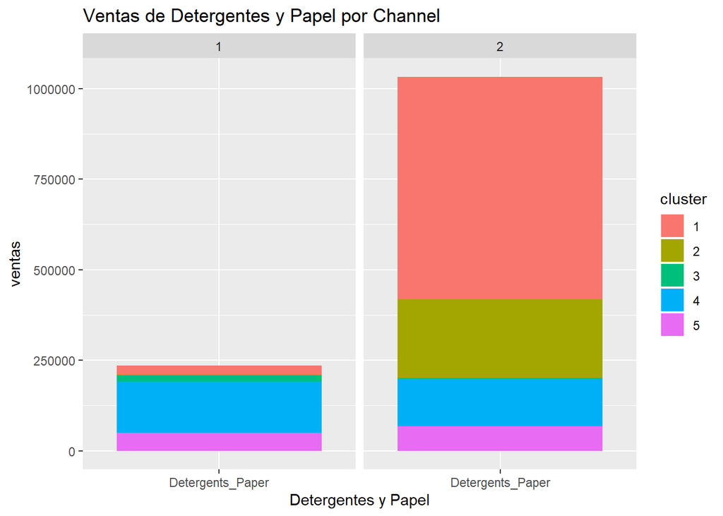

```r
ggplot(detergents_paper) +
    geom_bar(aes(x = variable, weight = value, fill=cluster)) +
    facet_wrap(~Channel) +
    labs(x = 'Detergentes y Papel', y  = 'ventas') +
    ggtitle('Ventas de Detergentes y Papel por Channel')
```

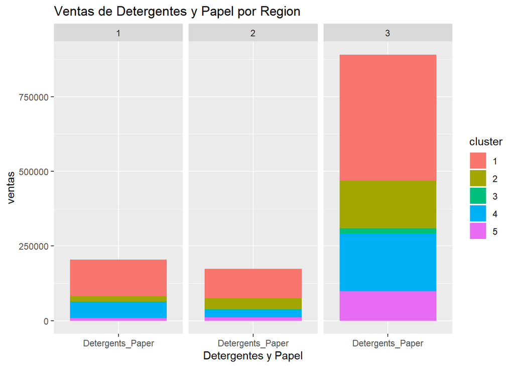

```r
ggplot(detergents_paper) +
    geom_bar(aes(x = variable, weight = value, fill=cluster)) +
    facet_wrap(~Region) +
    labs(x = 'Detergentes y Papel', y  = 'ventas') +
    ggtitle('Ventas de Detergentes y Papel por Region')
```